# R pour grands débutants

Partie 3 · Séances 7 à 10 — Graphiques, packages, dplyr & ggplot2, projet final

Aroo Falinirina

## Au programme

- **Séance 7** : graphiques avec R de base
- **Séance 8** : packages, dplyr et ggplot2 — **à côté de leurs équivalents en R de base**
- **Séance 9** : séance d’exercices
- **Séance 10** : projet final sur la couverture corallienne

~15 min graphiques · ~25 min packages/dplyr/ggplot2 · ~5 min exercices · ~15 min projet final.

## Séance 7 — Graphiques avec R de base

## Quel graphique pour quelle question ?

| Question | Graphique | Fonction |
| --- | --- | --- |
| Distribution d’une variable ? | histogramme | `hist()` |
| Deux variables liées ? | nuage de points | `plot(x, y)` |
| Différences entre groupes ? | boxplot | `boxplot(y ~ g)` |
| Comparer des moyennes ? | barres + barres d’erreur | `barplot()` + `arrows()` |
| Effectifs par catégorie ? | barres | `barplot(table(x))` |

## Histogramme

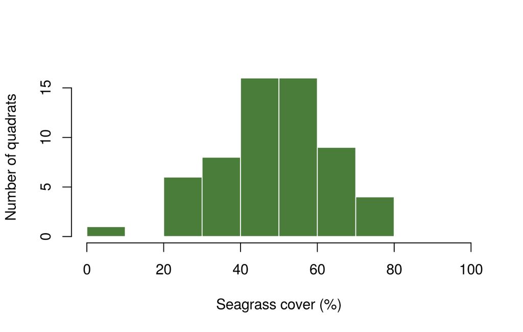

```r
hist(sg$seagrass_cover, breaks = seq(0, 100, by = 10),
     col = "#4a7d3a", border = "white", main = "",
     xlab = "Seagrass cover (%)", ylab = "Number of quadrats")
```

## Nuage de points, couleurs, légende

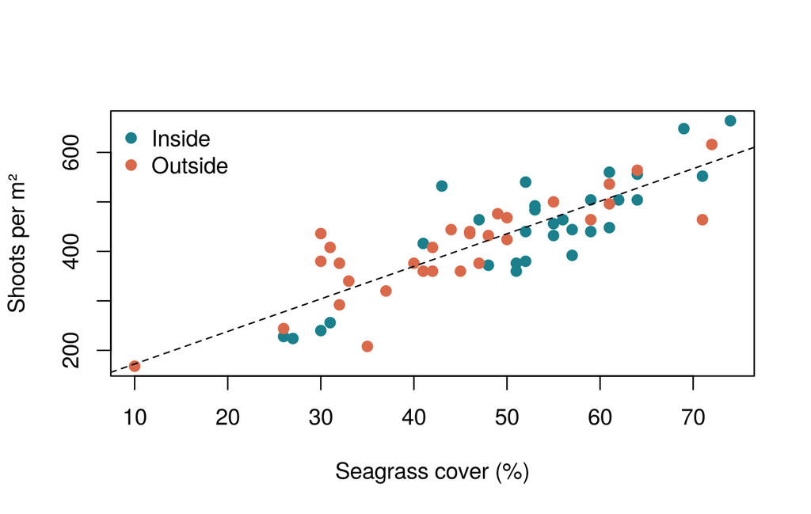

```r
cols <- c(Inside = "#1b7f8c", Outside = "#d9694a")
plot(sg$seagrass_cover, sg$shoot_density, pch = 19, col = cols[sg$mpa_status],
     xlab = "Seagrass cover (%)", ylab = "Shoots per m²")
legend("topleft", legend = names(cols), col = cols, pch = 19, bty = "n")
abline(lm(shoot_density ~ seagrass_cover, data = sg), lty = 2)
```

## Boxplot

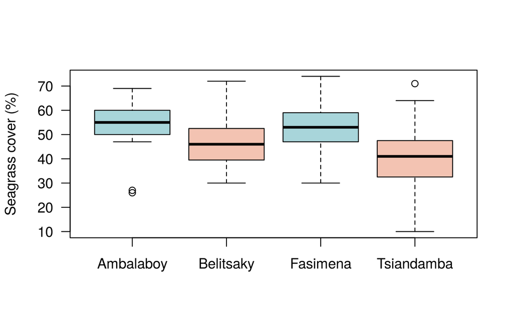

```r
boxplot(seagrass_cover ~ site, data = sg, las = 1, xlab = "",
        col = c("#a8d5da", "#f3c3b2", "#a8d5da", "#f3c3b2"),
        ylab = "Seagrass cover (%)")
```

## Moyennes ± ET : la figure des rapports

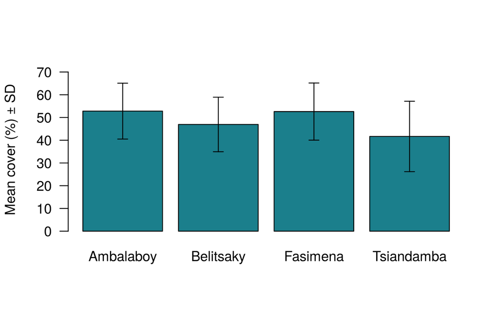

```r
m  <- tapply(sg$seagrass_cover, sg$site, mean)
s  <- tapply(sg$seagrass_cover, sg$site, sd)
bp <- barplot(m, ylim = c(0, max(m + s) * 1.1), col = "#1b7f8c", las = 1,
              ylab = "Mean cover (%) ± SD")
arrows(bp, m - s, bp, m + s, angle = 90, code = 3, length = 0.06)
```

## Plusieurs graphiques, enregistrer

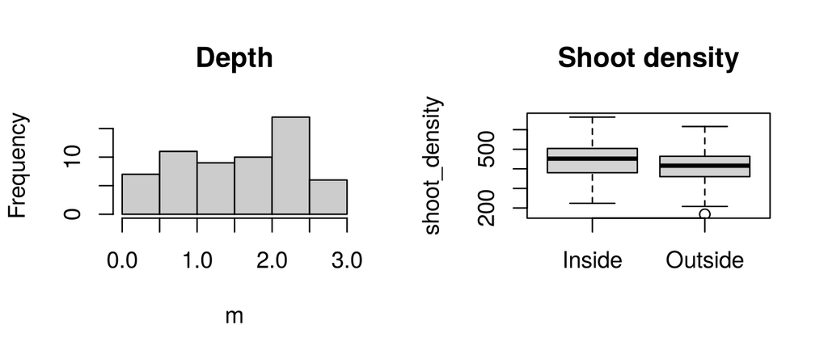

```r
par(mfrow = c(1, 2))
hist(sg$depth_m, main = "Depth", xlab = "m", col = "grey80")
boxplot(shoot_density ~ mpa_status, data = sg, main = "Shoot density", xlab = "")
```

```r
par(mfrow = c(1, 1))
```

```r
png("outputs/fig.png", width = 16, height = 11, units = "cm", res = 300)
boxplot(seagrass_cover ~ site, data = sg)
dev.off()                          # indispensable : écrit le fichier
```

## Séance 8 — Packages, dplyr et ggplot2

## Qu’est-ce qu’un package ?

[figure not shown]

## Installer une fois, charger à chaque fois

- **R de base** = déjà des packages : `base`, `stats`, `graphics`, `utils`, `tools`…
- **CRAN** : plus de 20 000 packages (`vegan`, `sf`, `lme4`…)
- **tidyverse** : `dplyr` (données), `ggplot2` (graphiques), `tidyr`, `readr`…

```r
install.packages(c("dplyr", "ggplot2"))   # UNE FOIS, dans la console
library(dplyr)                            # EN HAUT DE CHAQUE SCRIPT
library(ggplot2)
dplyr::filter(sg, seagrass_cover > 80)    # :: sans charger
citation("dplyr")                         # citer le package
```

« *masked* » au chargement : normal (ex. `filter` de **stats**). « *there is no package* » : pas encore installé.

## Le pipe `|>` = « puis »

```r
round(mean(sg$seagrass_cover), 1)          # imbriqué : de l'intérieur vers l'extérieur
```

```
#> [1] 48.5
```

```r
sg$seagrass_cover |> mean() |> round(1)    # enchaîné : de gauche à droite
```

```
#> [1] 48.5
```

- Raccourci **Ctrl + Maj + M** ; `%>%` (ancien) fait la même chose

## `filter()` ↔︎ `subset()` / `[ , ]`

R de base

```r
subset(sg, mpa_status == "Inside" &
           seagrass_cover > 75,
       select = c(site, quadrat,
                  seagrass_cover))
```

```
#> [1] site           quadrat        seagrass_cover
#> <0 rows> (or 0-length row.names)
```

dplyr

```r
sg |>
  filter(mpa_status == "Inside",
         seagrass_cover > 75) |>
  select(site, quadrat,
         seagrass_cover)
```

```
#> [1] site           quadrat        seagrass_cover
#> <0 rows> (or 0-length row.names)
```

## `select()` et `rename()`

R de base

```r
names(sg[, c("site", "date")])
```

```
#> [1] "site" "date"
```

```r
names(sg[, -c(4, 5)])
```

```
#> [1] "site"             "mpa_status"       "quadrat"          "species"
#> [5] "seagrass_cover"   "canopy_height_cm" "shoot_density"
```

```r
sg2 <- sg
names(sg2)[7] <- "cover_pct"
names(sg2)[7]
```

```
#> [1] "cover_pct"
```

dplyr

```r
names(select(sg, site, date))
```

```
#> [1] "site" "date"
```

```r
names(select(sg, -date, -depth_m))
```

```
#> [1] "site"             "mpa_status"       "quadrat"          "species"
#> [5] "seagrass_cover"   "canopy_height_cm" "shoot_density"
```

```r
sg2 <- rename(sg,
              cover_pct = seagrass_cover)
names(sg2)[7]
```

```
#> [1] "cover_pct"
```

## `mutate()` ↔︎ `df$col <- ...`

R de base

```r
f <- fish
f$biomass_g <- f$count * f$a *
               f$length_cm^f$b
f$kg_ha <- f$biomass_g / 1000 /
           250 * 10000
round(head(f$kg_ha, 4), 1)
```

```
#> [1]  28.0  16.5  65.3 213.6
```

dplyr

```r
f <- fish |>
  mutate(biomass_g = count * a *
                     length_cm^b,
         kg_ha = biomass_g / 1000 /
                 250 * 10000)
round(head(f$kg_ha, 4), 1)
```

```
#> [1]  28.0  16.5  65.3 213.6
```

## `arrange()` ↔︎ `order()`

R de base

```r
o <- order(sg$seagrass_cover,
           decreasing = TRUE)
head(sg[o, c("site",
             "seagrass_cover")], 4)
```

```
#>          site seagrass_cover
#> 28   Fasimena             74
#> 58  Belitsaky             72
#> 23   Fasimena             71
#> 42 Tsiandamba             71
```

dplyr

```r
sg |>
  arrange(desc(seagrass_cover)) |>
  select(site, seagrass_cover) |>
  head(4)
```

```
#>         site seagrass_cover
#> 1   Fasimena             74
#> 2  Belitsaky             72
#> 3   Fasimena             71
#> 4 Tsiandamba             71
```

## `group_by()` + `summarise()` ↔︎ `tapply()`

R de base

```r
m <- tapply(sg$seagrass_cover,
            sg$site, mean)
s <- tapply(sg$seagrass_cover,
            sg$site, sd)
data.frame(site = names(m),
           mean = as.vector(m),
           sd = as.vector(s))
```

```
#>         site     mean       sd
#> 1  Ambalaboy 52.80000 12.28937
#> 2  Belitsaky 46.93333 11.99087
#> 3   Fasimena 52.60000 12.56298
#> 4 Tsiandamba 41.66667 15.48578
```

dplyr

```r
sg |>
  group_by(site) |>
  summarise(mean = mean(seagrass_cover),
            sd = sd(seagrass_cover))
```

```
#> # A tibble: 4 × 3
#>   site        mean    sd
#>   <chr>      <dbl> <dbl>
#> 1 Ambalaboy   52.8  12.3
#> 2 Belitsaky   46.9  12.0
#> 3 Fasimena    52.6  12.6
#> 4 Tsiandamba  41.7  15.5
```

## `count()` ↔︎ `table()`

R de base

```r
table(fish$family)
```

```
#>
#>   Acanthuridae Chaetodontidae       Labridae     Lutjanidae       Scaridae
#>             22             19             16             20             33
#>     Serranidae      Siganidae
#>             16             15
```

dplyr

```r
count(fish, family)
```

```
#>           family  n
#> 1   Acanthuridae 22
#> 2 Chaetodontidae 19
#> 3       Labridae 16
#> 4     Lutjanidae 20
#> 5       Scaridae 33
#> 6     Serranidae 16
#> 7      Siganidae 15
```

## ggplot2 : la grammaire des graphiques

1. `ggplot(données, aes(x = ..., y = ..., colour = ...))` — données + **esthétique**
2. `+ geom_*()` — la forme : `geom_point()`, `geom_boxplot()`, `geom_col()`, `geom_errorbar()`…
3. `+ labs()`, `+ theme_*()`, `+ scale_*()`, `+ facet_wrap()`

R de base : on trace, puis on **ajoute** (`points()`, `arrows()`, `legend()`). ggplot2 : on **empile des couches** avec `+`. Même logique, syntaxe différente.

## Nuage de points : base ↔︎ ggplot2

R de base

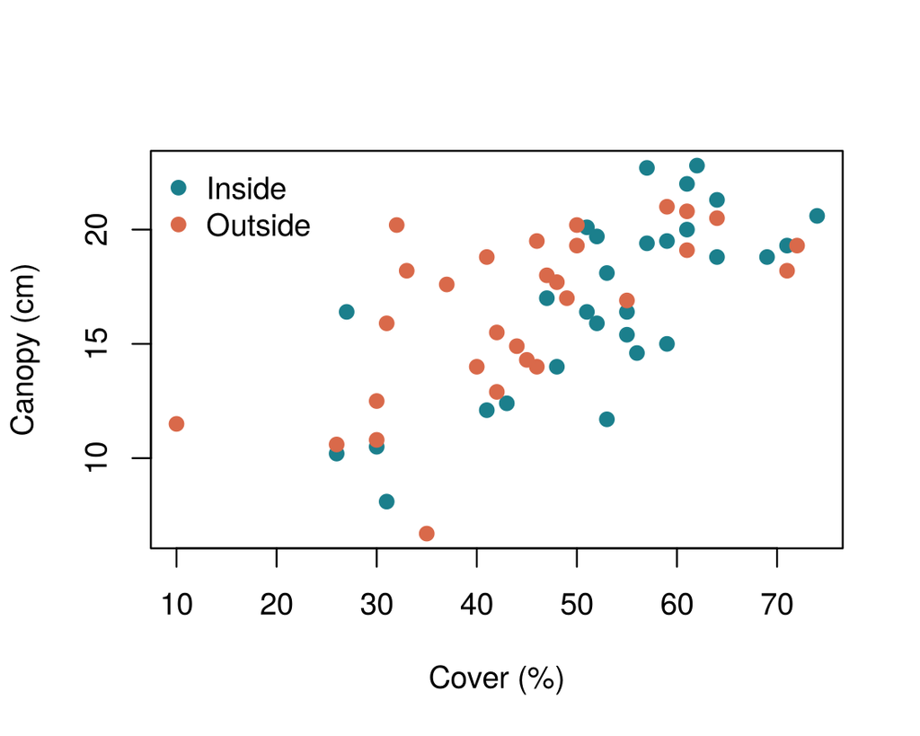

```r
plot(sg$seagrass_cover,
     sg$canopy_height_cm, pch = 19,
     col = cols[sg$mpa_status],
     xlab = "Cover (%)",
     ylab = "Canopy (cm)")
legend("topleft", names(cols),
       col = cols, pch = 19, bty = "n")
```

ggplot2

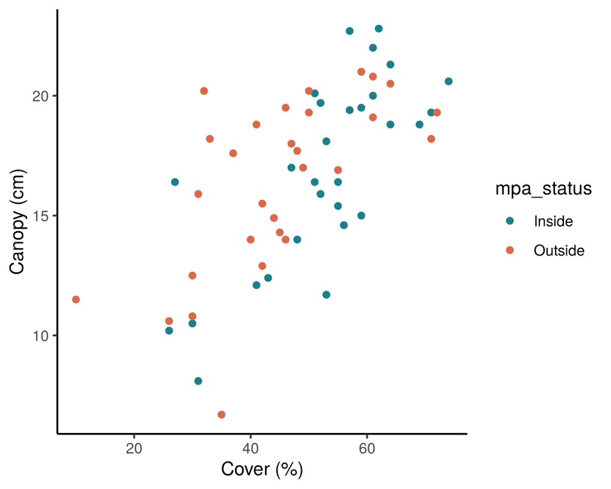

```r
ggplot(sg, aes(seagrass_cover,
               canopy_height_cm,
               colour = mpa_status)) +
  geom_point(na.rm = TRUE) +
  scale_colour_manual(values = cols) +
  labs(x = "Cover (%)",
       y = "Canopy (cm)") +
  theme_classic()
```

## Boxplot : base ↔︎ ggplot2

R de base

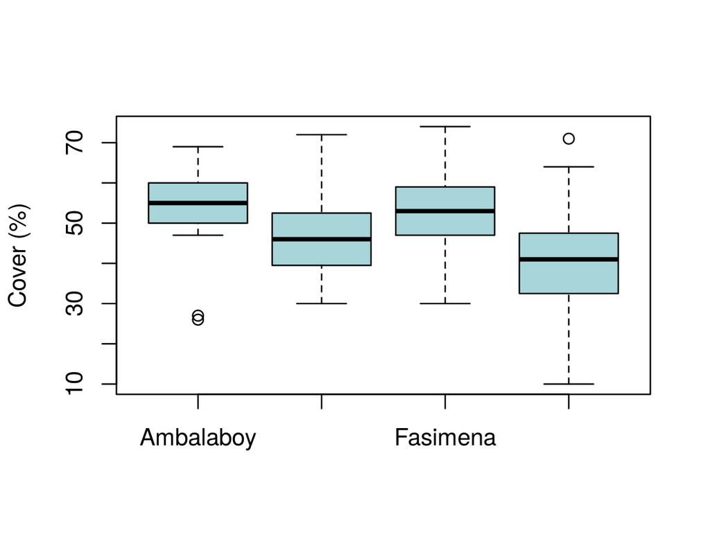

```r
boxplot(seagrass_cover ~ site,
        data = sg, col = "#a8d5da",
        xlab = "", ylab = "Cover (%)")
```

ggplot2

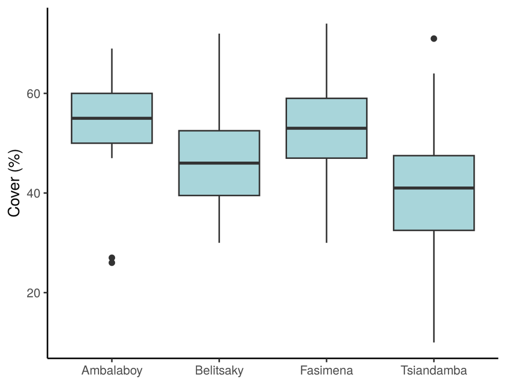

```r
ggplot(sg, aes(site,
               seagrass_cover)) +
  geom_boxplot(fill = "#a8d5da") +
  labs(x = NULL, y = "Cover (%)") +
  theme_classic()
```

## Moyennes ± ET : base ↔︎ ggplot2

R de base

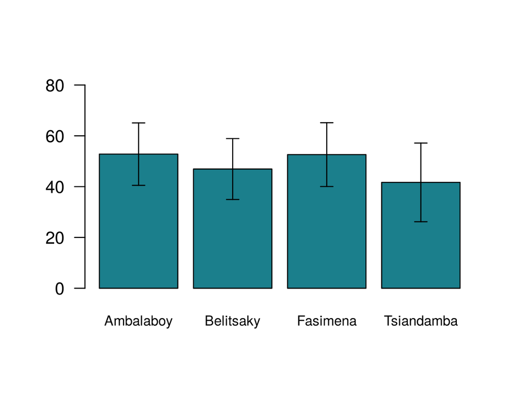

```r
m <- tapply(sg$seagrass_cover, sg$site, mean)
s <- tapply(sg$seagrass_cover, sg$site, sd)
bp <- barplot(m, ylim = c(0, 80),
              col = "#1b7f8c", las = 1,
              cex.names = 0.8)
arrows(bp, m - s, bp, m + s,
       angle = 90, code = 3,
       length = 0.06)
```

ggplot2

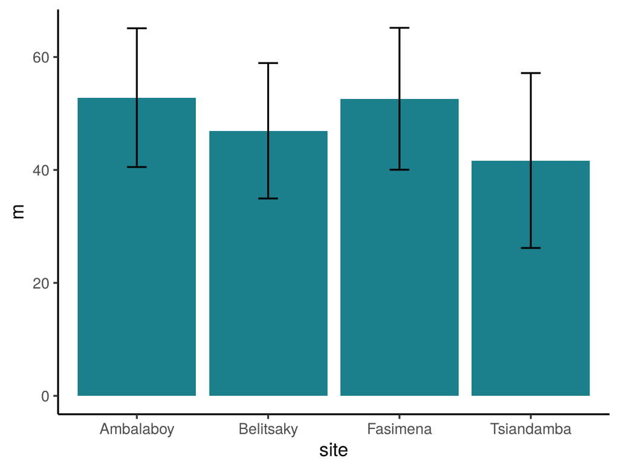

```r
sm <- sg |> group_by(site) |>
  summarise(m = mean(seagrass_cover),
            s = sd(seagrass_cover))
ggplot(sm, aes(site, m)) +
  geom_col(fill = "#1b7f8c") +
  geom_errorbar(aes(ymin = m - s,
                    ymax = m + s),
                width = 0.15) +
  theme_classic()
```

## Un panneau par groupe, enregistrer

R de base

```r
par(mfrow = c(2, 2))
by_site <- split(sg$seagrass_cover, sg$site)
hist(by_site$Ambalaboy)
hist(by_site$Belitsaky)
# ... un par site
par(mfrow = c(1, 1))

png("outputs/fig.png", width = 16,
    height = 11, units = "cm", res = 300)
boxplot(seagrass_cover ~ site, data = sg)
dev.off()
```

ggplot2

```r
ggplot(sg, aes(seagrass_cover)) +
  geom_histogram(binwidth = 10) +
  facet_wrap(~ site)

p <- ggplot(sg, aes(site,
                    seagrass_cover)) +
  geom_boxplot()
ggsave("outputs/fig.png", p,
       width = 16, height = 11,
       units = "cm", dpi = 300)
```

## Même idée, noms d’arguments différents

| Réglage | R de base | ggplot2 |
| --- | --- | --- |
| remplissage | `col` | `fill` |
| contour / points | `border`, `col` | `colour` |
| taille, forme des points | `cex`, `pch` | `size`, `shape` |
| titres | `main`, `xlab`, `ylab` | `labs(title, x, y)` |
| classes d’histogramme | `breaks` | `binwidth` |
| résolution | `res` dans `png()` | `dpi` dans `ggsave()` |

## Séance 9 — Séance d’exercices

## Six exercices pour s’entraîner

| Ex. | Thème | Révision |
| --- | --- | --- |
| 1 | Créer des vecteurs : `seq`, `rep`, `sample`, `sort`, `paste` | séance 2 |
| 2 | Adresses `[ligne, colonne]`, modifier des valeurs | séances 3–4 |
| 3 | Colonnes calculées (biomasse), suppression, `sapply` | séance 4 |
| 4 | `subset()`, `%in%`, nettoyage de texte et de nombres | séance 5 |
| 5 | Statistiques par groupe, une valeur par transect | séance 6 |
| 6 | Graphiques ; équivalences R de base ↔︎ tidyverse | séances 7–8 |

Un quiz par exercice, **deux tentatives** (la meilleure compte) : vérifier dans le script avant de valider.

## Séance 10 — Projet final

## Le suivi corallien

- **3 AMP** (Ankaramena, Nosy Fasika, Tanjona — noms inventés, données simulées)
- 2 zones par AMP : **No-take** (pêche interdite) et **Fishing**
- 3 transects de 25 m par zone · **50 points** par transect (PIT)
- Fichier `coral_cover_raw.csv` : **910 lignes**, saisi par 3 observateurs… et sale

**Question** : la couverture en corail dur est-elle plus élevée en zone No-take, et ce dans les trois AMP ?

## La méthode PIT

[figure not shown]

## Les étapes

[figure not shown]

## Étape 1–2 : importer et nettoyer

```r
raw <- read.csv("data/coral_cover_raw.csv")
length(unique(raw$mpa))                             # 15 orthographes !
```

```
#> [1] 15
```

```r
raw$mpa <- tools::toTitleCase(tolower(trimws(gsub("\\s+", " ", raw$mpa))))
raw$zone[tolower(raw$zone) == "no-take"] <- "No-take"
raw$zone[tolower(raw$zone) == "fishing"] <- "Fishing"
raw$category <- toupper(trimws(raw$category))
raw$category[raw$category == ""] <- NA
pts <- raw[!duplicated(raw), ]
pts <- pts[!is.na(pts$category), ]
table(pts$mpa, pts$zone)
```

```
#>
#>               Fishing No-take
#>   Ankaramena      147     147
#>   Nosy Fasika     148     146
#>   Tanjona         150     148
```

## Étape 3 : la base de données (1 ligne = 1 transect)

```r
pts$is_hc <- pts$category == "HC"           # TRUE si corail dur
db <- aggregate(is_hc ~ mpa + zone + transect, data = pts, FUN = mean)
db$hc_cover <- db$is_hc * 100               # moyenne de TRUE/FALSE = proportion
db$is_hc <- NULL
nrow(db)
```

```
#> [1] 18
```

```r
head(db, 4)
```

```
#>           mpa    zone transect hc_cover
#> 1  Ankaramena Fishing        1 34.00000
#> 2 Nosy Fasika Fishing        1 36.00000
#> 3     Tanjona Fishing        1 16.00000
#> 4  Ankaramena No-take        1 38.77551
```

## Étape 4 : moyenne et ET par AMP × zone

```r
m <- tapply(db$hc_cover, list(db$zone, db$mpa), mean)
s <- tapply(db$hc_cover, list(db$zone, db$mpa), sd)
round(m, 1)
```

```
#>         Ankaramena Nosy Fasika Tanjona
#> Fishing       29.9        28.3    21.3
#> No-take       38.0        37.1    51.3
```

```r
round(s, 1)
```

```
#>         Ankaramena Nosy Fasika Tanjona
#> Fishing        6.0        10.5     4.6
#> No-take        8.4        13.1     7.5
```

## Étape 5 : la figure

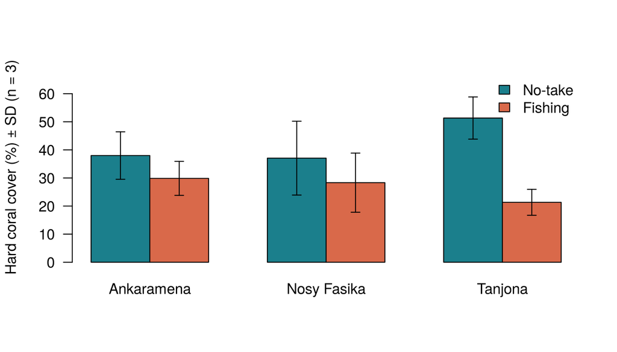

```r
m <- m[c("No-take", "Fishing"), ]; s <- s[c("No-take", "Fishing"), ]
bp <- barplot(m, beside = TRUE, ylim = c(0, max(m + s) * 1.15), las = 1,
              col = c("#1b7f8c", "#d9694a"), ylab = "Hard coral cover (%) ± SD (n = 3)")
arrows(bp, m - s, bp, m + s, angle = 90, code = 3, length = 0.05)
legend("topright", fill = c("#1b7f8c", "#d9694a"), legend = rownames(m), bty = "n")
```

## Étape 6 : interpréter avec prudence

- Où la couverture est-elle la plus forte ? L’effet No-take est-il le même partout ?
- **Limites** : n = 3 transects par zone, ET élevés, données simulées
- Une figure n’existe qu’avec sa **légende** : ce que montrent les barres, les barres d’erreur, et n

Le quiz final reprend chaque étape : nombre de lignes, doublons, points manquants, couverture d’un transect, moyennes et ET.

## Et ensuite ?

**Niveau intermédiaire** (débloqué avec 75 % des points du niveau débutant) :

- vrais fichiers : Excel à plusieurs feuilles, dates, restructurer, joindre, enquêtes
- programmation : `if` / `else`, boucles `for`, écrire ses propres fonctions
- maîtriser ggplot2 et premières cartes
- distributions, p-values, comparer des moyennes et des pourcentages, corrélations